# 09_Linear Models Extended

# Housekeeping

**Literature presentations** - assign groups today.

Spend next Tuesday recording them. I’d like them ready by Thursday. I’ll set up a Box folder where they should be uploaded.

**Problem Set** is incoming but it’s mostly about asking you to simulate and visualize data to build intuition about linear models. Slowly working my way through grading

```r
library(tidyverse);library(knitr)
mytheme <- theme_bw() + theme(panel.grid = element_blank())
```

# Lecture

What are the definitions for these terms?

- Predictor variable
- Response variable
- Residuals

Recall: $y_i = \beta_0 + \beta_1 x_i + e_{i}$, where $e$ describes the error, or variation unexplained by the best fit line. $\beta_0$, $\beta_1$, and $e$ are **model parameters** that are estimated through the least squares fitting process. The $\beta_i$ are also called **coefficients**.

### Transformations

Sometimes our response variables are

- non-normal (in the errors, assuming a linear model)
- non-linear (functional form)
- heteroskedastic (variance is related to a predictor)

Log transforming your response variable can be a quick fix, if it’s a positive-only variable. If $log(Y) = \beta_{0} + \beta_{1}X + \varepsilon$, this implies another model for the data *on the response scale (the original, untransformed data)*: $Y = e^{\beta_{0} + \beta_{1}X + \varepsilon}$.

**Multiplicative effects of predictors on response scale:** The terms are multiplied: $Y = e^{\beta_{0}}e^{\beta_{1}X}e^{\varepsilon}$. This is important to consider expectations for estimated values of $\beta_{i}$ (usually small) and interactions, which we’ll discuss later.

**Coefficient interpretation as relative/multiplicative effects:** The interpretation of the betas are the same on the log scale (i.e., $\beta_{1}=\frac{dy}{dx}$), but the effect on the response scale must be transformed. $e^{\beta_{X}}$ implies Y changes *proportionally* with changes in X,, so really $\frac{dy}{dx} =\beta_{1}Y$. In other words, on the scale of the original data, the **change in y with respect to x depends on the value of Y**, so it’s better interpreted in terms of relative change.

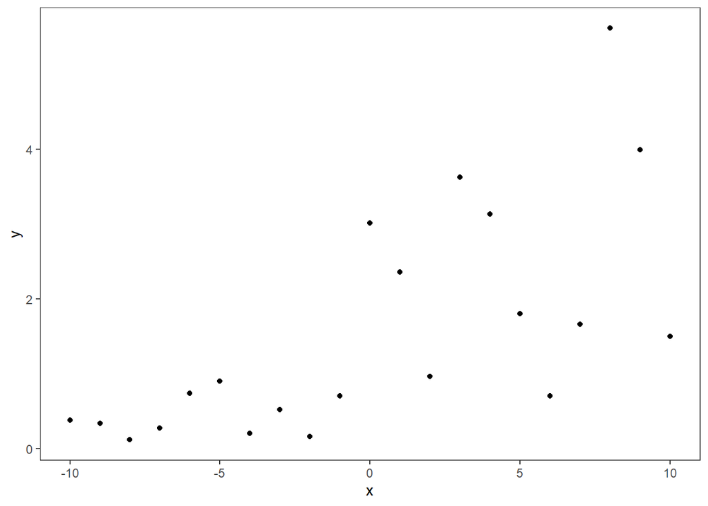

```r
set.seed(10)
df_log1 <- tibble(x = seq(-10,10, by = 1))|>
  mutate(e = rnorm(n(), 0, 1),
         y = exp(0.1*x + e),
         logy = log(y))


ggplot(df_log1, aes(x,y))+
  geom_point()+
  mytheme
```

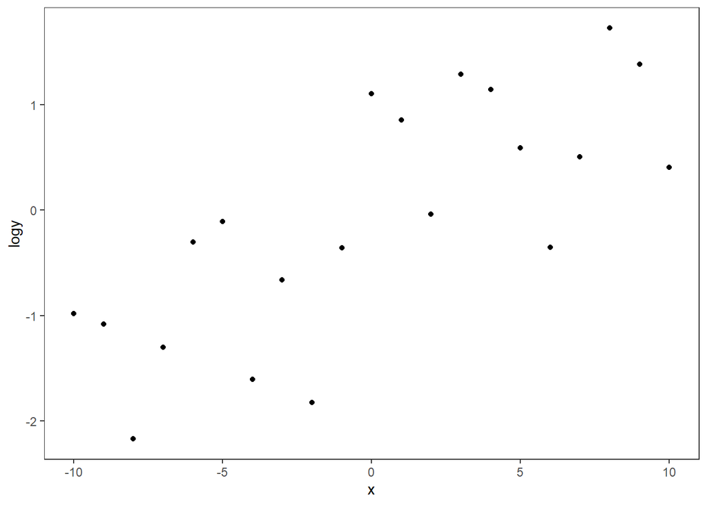

```r
ggplot(df_log1, aes(x,logy))+
  geom_point()+
  mytheme
```

We can **backtransform** to estimate regression coefficients meaningful on the original scale. So if we want our slope coefficient to be interpreted as proportional change on the response scale, we could take $100(e^{\beta_{1}}-1)$.

```r
log1_lm <- lm(data=df_log1, logy~x)

tibble(Term = c("Intercept", "Slope"),
       "Model (log) Scale" =  c(coef(log1_lm)[1],coef(log1_lm)[2]),
       "Response Scale" = c(exp(coef(log1_lm)[1]),exp(coef(log1_lm)[2])),
       "% Change/Unit Change X" = 100*(`Response Scale`-1))|>
  kable()
```

| Term | Model (log) Scale | Response Scale | % Change/Unit Change X |
| --- | --- | --- | --- |
| Intercept | -0.0860459 | 0.9175521 | -8.244789 |
| Slope | 0.1359723 | 1.1456501 | 14.565012 |

**Multiplicative errors**. We can demonstrate this both mathematically and visually.

First, Remember the error term is, on the response scale, $e^{\varepsilon_{i}}$.

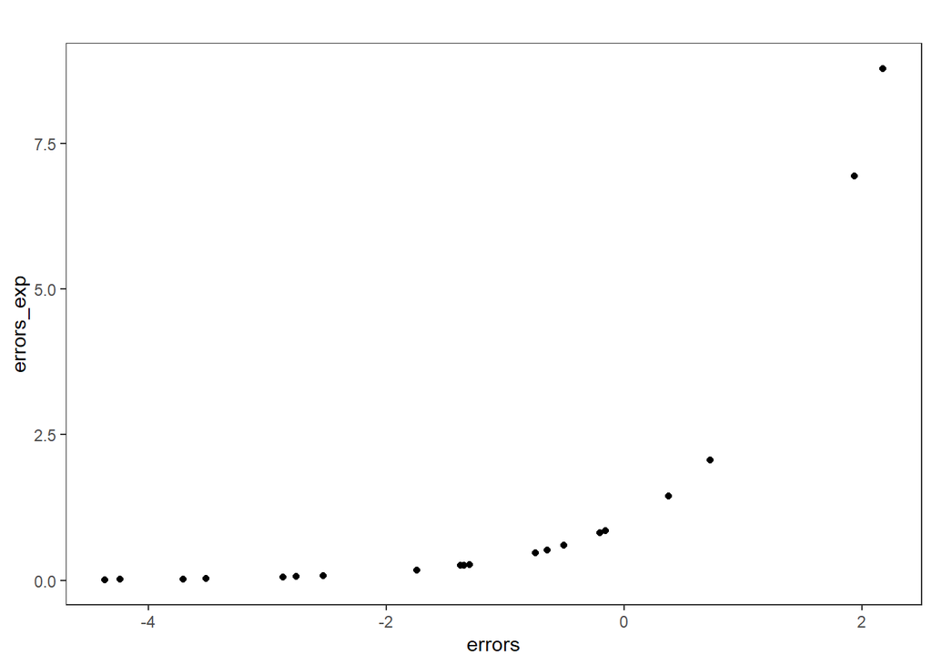

```r
errors_df <- tibble(errors = rnorm(20, 0, 2))|>
  mutate(errors_exp = exp(errors))

ggplot(errors_df, aes(x = errors, y = errors_exp))+
  geom_point()+
  mytheme+ggtitle("")
```

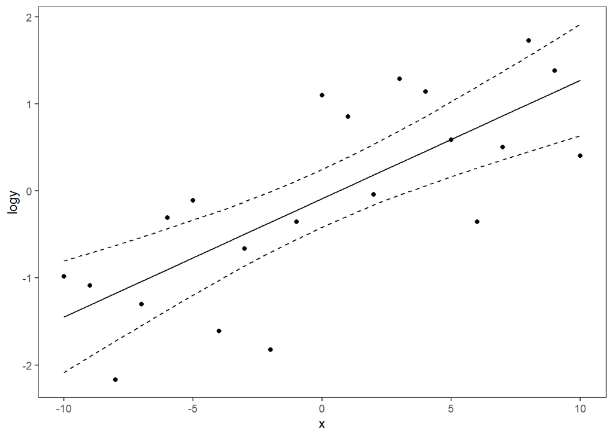

```r
log1_preds <- df_log1|>
  mutate(preds = predict(log1_lm, se.fit = TRUE)$fit,
         se = predict(log1_lm, se.fit = TRUE)$se.fit,
         upper_95CI = preds + se*1.96,
         lower_95CI = preds - se*1.96)

ggplot(log1_preds)+
  geom_point(aes(x = x, y = logy))+
  geom_line(aes(x = x, y = preds))+
  geom_line(aes(x = x, y = upper_95CI), linetype = "dashed")+
  geom_line(aes(x = x, y = lower_95CI), linetype = "dashed")+
  mytheme
```

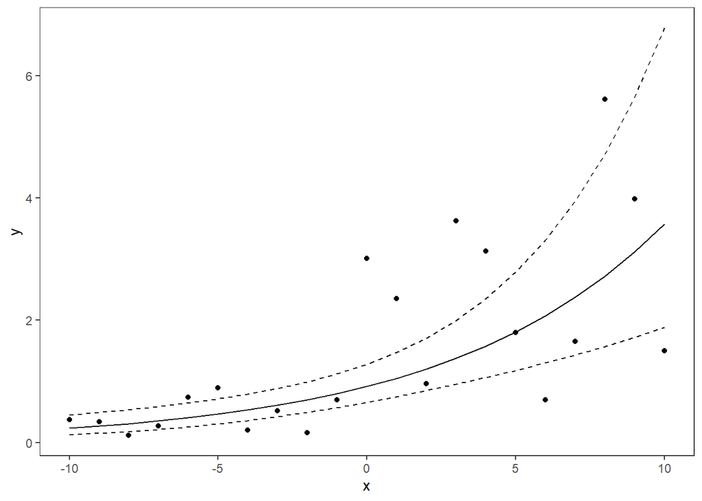

```r
ggplot(log1_preds)+
  geom_point(aes(x = x, y = y))+ #back to original y
  geom_line(aes(x = x, y = exp(preds)))+
  geom_line(aes(x = x, y = exp(upper_95CI)), linetype = "dashed")+
  geom_line(aes(x = x, y = exp(lower_95CI)), linetype = "dashed")+
  mytheme
```

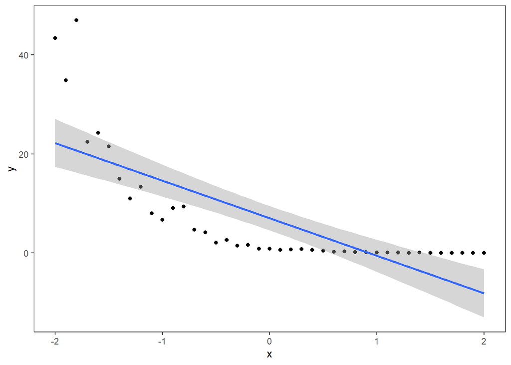

```r
df_l <- tibble(x = seq(-2,2, by = 0.1))|>
  mutate(e = rnorm(n(), 0,0.3),
         y = exp(-2*x + e))

ggplot(df_l, aes(x = x, y = y))+
  geom_point()+
  mytheme+geom_smooth(method = "lm")
```

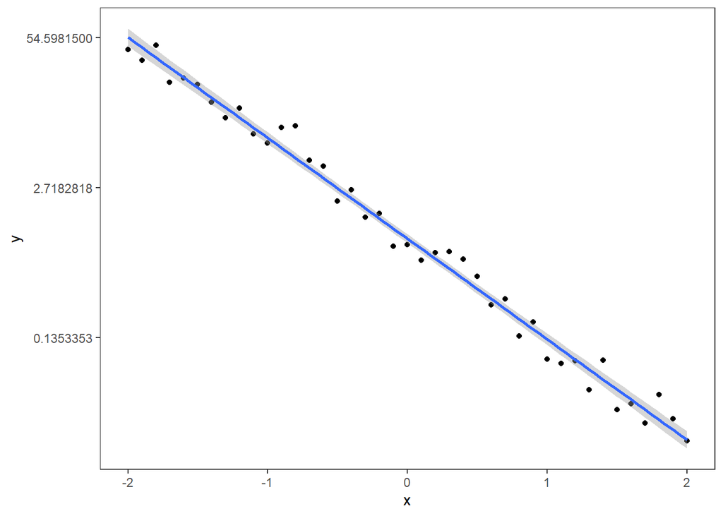

```r
ggplot(df_l, aes(x = x, y = y))+
  geom_point()+geom_smooth(method = "lm")+
  mytheme+
  scale_y_continuous(trans = "log")
```

What about when you have zeroes? y+n (e.g., y+1) transformation is bad.

Bigger picture of transformations: They’re often great, but be cognizant of how they may change the interpretation of your parameters and often the need to backtransform to the response scale.

### Categorical predictors

So we’ve focused on linear regression where $x_i$ is a continuous variable, so a line is an obvious interpretation. But what happens when we have a categorical predictor?

Let’s say we have a category a that’s been measured 5 times with a mean of 2 and a category b with a mean of 6, plus some noise.

[figure not shown]

What’s the influence of x on y here? Linear regression still works.

```r
lm_df<-lm(data = df_sim, y~ab)
coef(lm_df)
```

```
(Intercept)         abb
   2.008504    4.104716
```

What’s the slope in this context? What is the intercept? How does that work with letters?

This an example of dummy coding - x is an indicator variable.

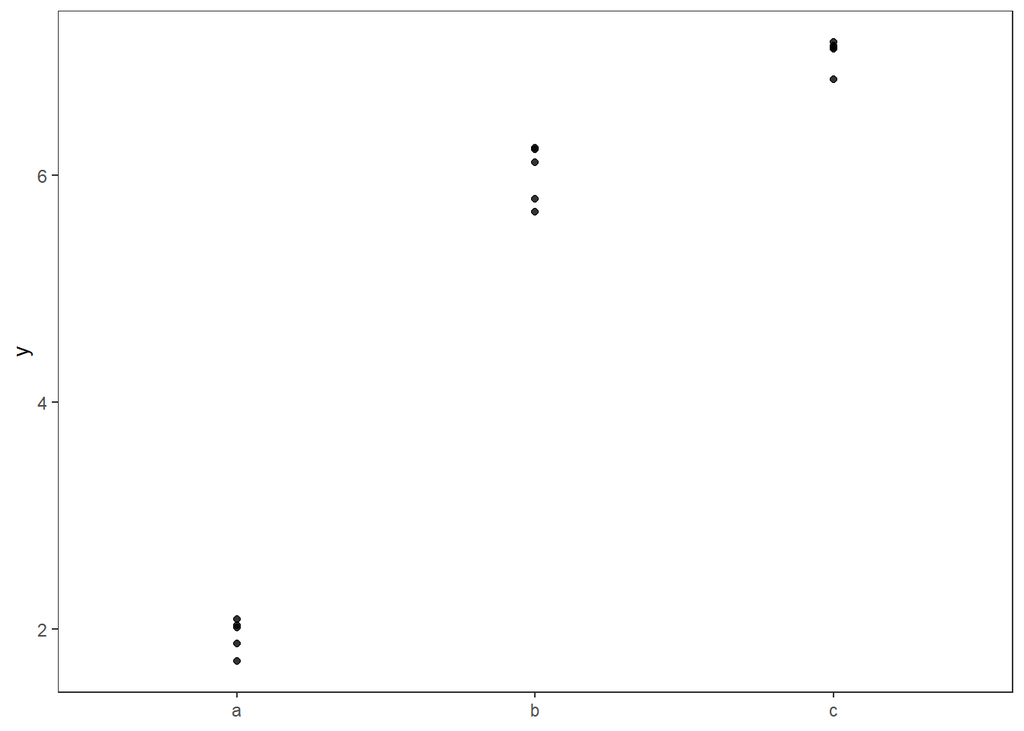

```r
df_sim2 <- tibble(x = rep(c(0,1,1.25), 5))|>
  mutate(e = rnorm(n(), 0, 0.2),
         y = 2+4*x + e,
         ab = ifelse(x == 0, "a",ifelse(x == 1, "b", "c")))

ggplot(df_sim2, aes(x = ab, y = y))+
  geom_point(alpha = 0.8)+
  mytheme+theme(axis.title.x = element_blank())
```

```r
lm_df2 <- lm(data = df_sim2, y ~ ab)
coef(lm_df2)
```

```
(Intercept)         abb         abc
   1.943369    4.068588    5.140576
```

### Regression with multiple predictors

Often called multiple regression (Not multivariate regression which is multiple response variables at once), this is just a linear model with multiple X variables, $\hat{Y} = \beta_{0} + \beta_{1}X_{1} + ... + \beta_{i}X_{i}$. The $\beta_{i}$s now represent partial derivatives $\frac{\partial y}{\partial x_{i}}$. So it’s the unit change in y with respect to a unit change in the X variable of interest *holding all other X variables constant*. These are also called *partial slopes* or *partial effects*.

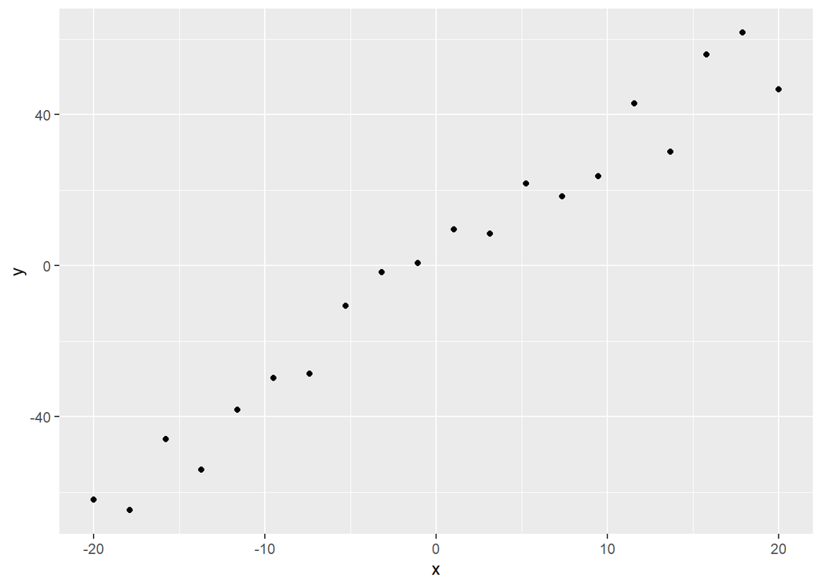

```r
mr_df1 <- tibble(x = seq(20,-20, length.out = 20),
                 z = seq(1,5, length.out = 20))|>
  mutate(e = rnorm(n(), 0, 8),
         y = 16 + 2.5*x + -6*z +e)

ggplot(mr_df1, aes(x = x, y = y))+
  geom_point()
```

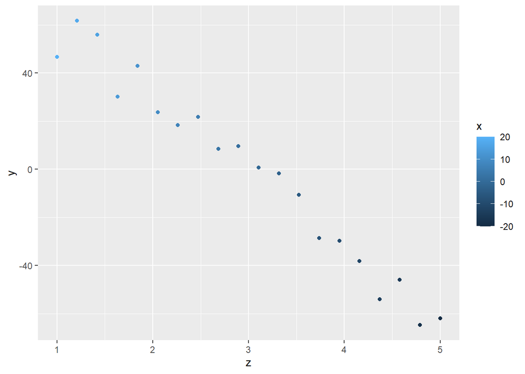

```r
ggplot(mr_df1, aes(x = z, y = y, color = x))+
  geom_point()
```

```r
mr_lm1 <- lm(data = mr_df1, y ~ x + z)
summary(mr_lm1)
```

```
Call:
lm(formula = y ~ x + z, data = mr_df1)

Residuals:
     Min       1Q   Median       3Q      Max
-14.9145  -4.9493   0.9324   6.5467   8.9115

Coefficients: (1 not defined because of singularities)
            Estimate Std. Error t value Pr(>|t|)
(Intercept)  -0.7966     1.6757  -0.475     0.64
x             3.1223     0.1380  22.619 1.14e-14 ***
z                 NA         NA      NA       NA
---
Signif. codes:  0 '***' 0.001 '**' 0.01 '*' 0.05 '.' 0.1 ' ' 1

Residual standard error: 7.494 on 18 degrees of freedom
Multiple R-squared:  0.966, Adjusted R-squared:  0.9641
F-statistic: 511.6 on 1 and 18 DF,  p-value: 1.139e-14
```

Uh oh. What’s happened here?

z turns out to be a function of x (or vice versa) - each are sequences matched by position - i.e. their *rank ordering* is the same. This is fundamentally correlation requires variation

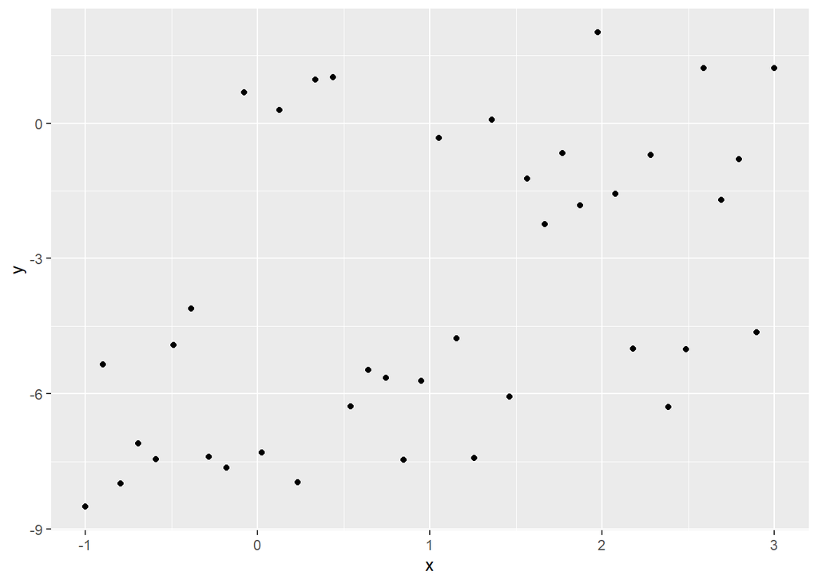

```r
length_seq <- 40
mr_df1 <- tibble(x = seq(3,-1, length.out = length_seq),
                 z = runif(length_seq,1,10))|>
  mutate(e = rnorm(n(), 0, 0.2),
         y = 2 + 0.5*x + -1*z +e)

ggplot(mr_df1, aes(x = x, y = y))+
  geom_point()
```

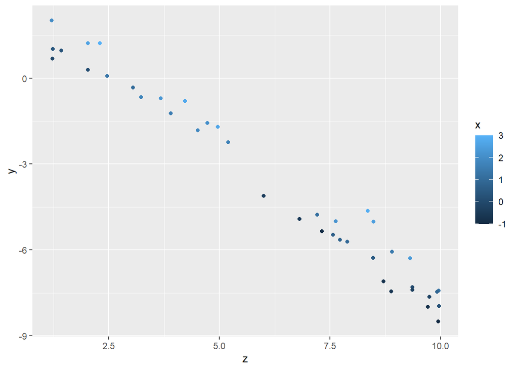

```r
ggplot(mr_df1, aes(x = z, y = y, color = x))+
  geom_point()
```

```r
mr_lm1 <- lm(data = mr_df1, y ~ x + z)
summary(mr_lm1)
```

```
Call:
lm(formula = y ~ x + z, data = mr_df1)

Residuals:
     Min       1Q   Median       3Q      Max
-0.39405 -0.11624 -0.02195  0.14943  0.37188

Coefficients:
            Estimate Std. Error t value Pr(>|t|)
(Intercept)  2.09270    0.08582   24.39   <2e-16 ***
x            0.46332    0.02729   16.98   <2e-16 ***
z           -1.01087    0.01075  -94.04   <2e-16 ***
---
Signif. codes:  0 '***' 0.001 '**' 0.01 '*' 0.05 '.' 0.1 ' ' 1

Residual standard error: 0.1924 on 37 degrees of freedom
Multiple R-squared:  0.9968,    Adjusted R-squared:  0.9966
F-statistic:  5760 on 2 and 37 DF,  p-value: < 2.2e-16
```

#### Visualizing multiple effects

Visualizing the model predictions helps us understand what the model is allowing and what the coefficients mean.

As we did in the last lecture, let’s create some newdata to predict on. The trick here is there’s no one right way to do it because there’s no single X variable. So let’s make predictions for x for different levels of z. How do we do that if it’s not a factor variable?

```r
range(mr_df1$z)
```

```
[1] 1.206303 9.960539
```

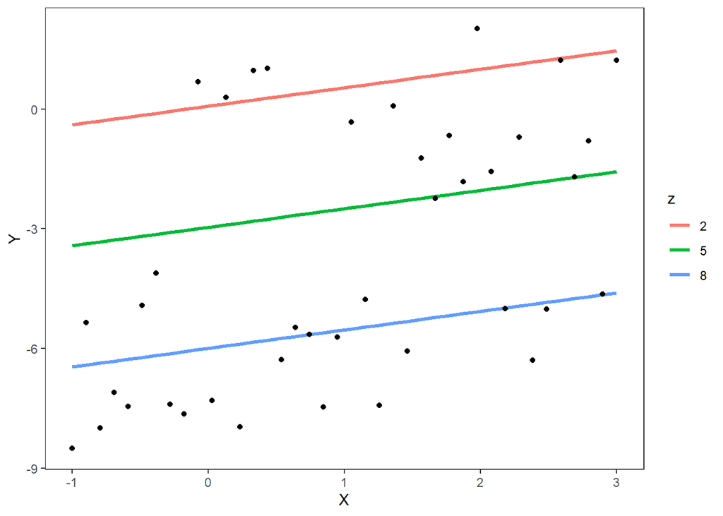

```r
new_data <- tibble(z = c(2,5,8))|>
  expand_grid(x = mr_df1$x)


  pred_df <- tibble(preds = predict(mr_lm1, newdata = new_data))|>bind_cols(new_data)|>
    mutate(z = as_factor(z))

ggplot()+
  geom_line(data = pred_df, aes(x = x, y = preds, color = z), linewidth = 1.1)+
  geom_point(data = mr_df1, aes(x = x, y = y))+
  labs(y = "Y", x = "X")+
  theme_bw()+theme(panel.grid = element_blank())
```

So $\beta_{1}$ here is the slope of Y~X. How does $\beta_{2}$ play in here? $\beta_{2}$ from the model was -1.0108657. Let’s make it easier to see.

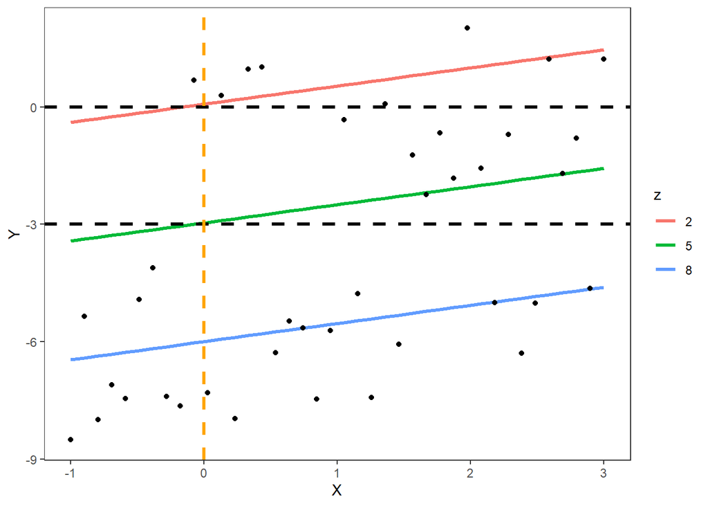

```r
ggplot()+
  geom_line(data = pred_df, aes(x = x, y = preds, color = z), linewidth =1.1)+
  geom_point(data = mr_df1, aes(x = x, y = y))+
  labs(y = "Y", x = "X")+
  theme_bw()+theme(panel.grid = element_blank())+
  geom_hline(yintercept = c(0,-3), linetype = "dashed", linewidth = 1.1)+geom_vline(xintercept = 0, color = "orange", linetype = "dashed", linewidth = 1.1)
```

Note that as you add more predictors it gets increasingly impossible to visualize all their combined effects at once. This is just dimensionality.

But a bigger picture way to look at this is adding a predictor is like **adjusting the intercept of one regression for different levels of second predictor variable**. This is fundamentally what you’re doing in ANOVA, just categorical variables so you’re not dealing with continuous slopes. But not to be confusing the term “intercept”, what is $\beta_{0}$ here?

#### Interactions

What if we don’t just want the intercept of a relationship to vary? What if we want the implied slopes for different levels of a variable to be different? This is where **interactions** come in. Interactions are terms that are a new $\beta_{i}$ but it’s X values are a multiplication of two other predictor variables. Practically, this means that the slope, not just the y intercept, depends on the values of two different X values.

So let’s introduce a third term. And then in the `lm()` formula syntax, an interaction is specified with a `:` with the two variables on each side, `x:z`. But note that if you specify `x*z`, this will automamtically expand to include the **main effects** for the two terms, so it is equivalent to `x + z + x:z`. You usually want those main effects. What happens otherwise?

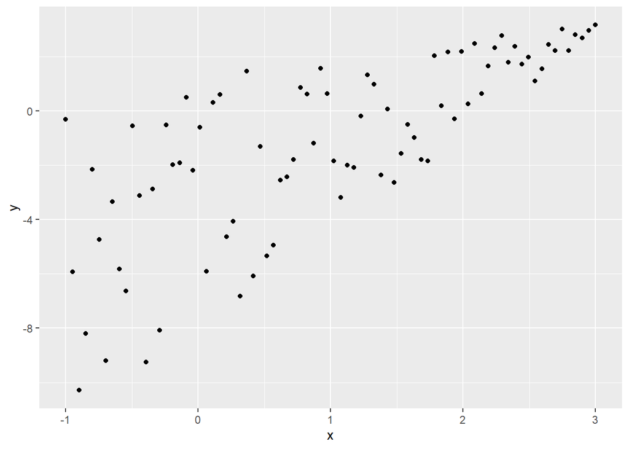

```r
length_seq <- 80
mr_df1 <- tibble(x = seq(3,-1, length.out = length_seq),
                 z = runif(length_seq,1,10))|>
  mutate(xz = x*z,
         e = rnorm(n(), 0, 0.2),
         y = 2 + 0.5*x + -1*z +0.3*xz + e)

ggplot(mr_df1, aes(x = x, y = y))+
  geom_point()
```

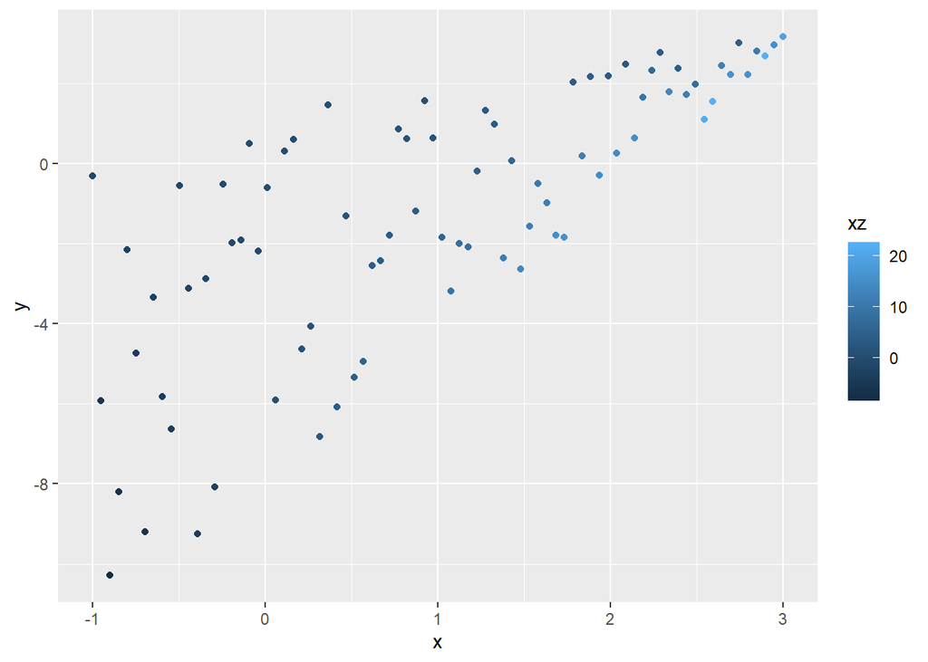

```r
ggplot(mr_df1, aes(x = x, y = y, color = xz))+
  geom_point()
```

```r
mr_lmint <- lm(data = mr_df1, y ~ x + z + x:z)
summary(mr_lmint)
```

```
Call:
lm(formula = y ~ x + z + x:z, data = mr_df1)

Residuals:
     Min       1Q   Median       3Q      Max
-0.50462 -0.14636  0.00172  0.14704  0.46449

Coefficients:
             Estimate Std. Error t value Pr(>|t|)
(Intercept)  2.057969   0.064373   31.97  < 2e-16 ***
x            0.458575   0.044923   10.21 6.71e-16 ***
z           -1.004253   0.010650  -94.29  < 2e-16 ***
x:z          0.304206   0.007681   39.60  < 2e-16 ***
---
Signif. codes:  0 '***' 0.001 '**' 0.01 '*' 0.05 '.' 0.1 ' ' 1

Residual standard error: 0.1997 on 76 degrees of freedom
Multiple R-squared:  0.9965,    Adjusted R-squared:  0.9964
F-statistic:  7242 on 3 and 76 DF,  p-value: < 2.2e-16
```

Remember $\beta_{1} is the slope when z = 0.

Okay, let’s predict again to visualize the implied relationships.

The newdata argument is the same, but why don’t we need to create a new values for xz to predict on?

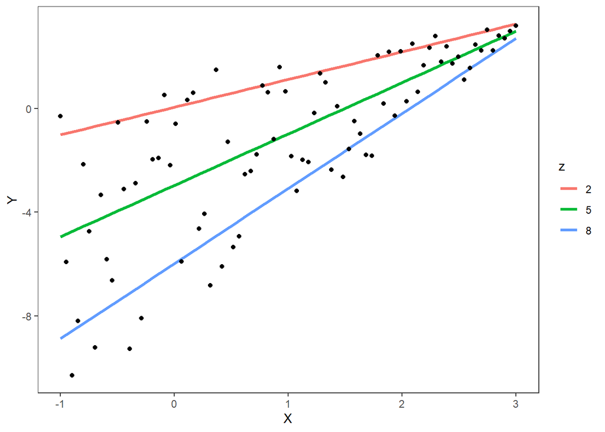

```r
  pred_dfint <- tibble(preds = predict(mr_lmint, newdata = new_data))|>bind_cols(new_data)|>
    mutate(z = as_factor(z))

ggplot()+
  geom_line(data = pred_dfint, aes(x = x, y = preds, color = z), linewidth = 1.1)+
  geom_point(data = mr_df1, aes(x = x, y = y))+
  labs(y = "Y", x = "X")+
  theme_bw()+theme(panel.grid = element_blank())
```

A note on interactions and sample sizes. Some say you need about 4 times the sample size to detect an interaction in your datasets as you need to detect an additive effect.

What happens when you simulate data without an interaction and fit a model with an interaction? Or vice versa?

#### Diagnostics

Diagnostics are the same as for simple linear regression! qqplots and residuals vs predicted plots. But with multiple predictors you may need to check for homoskedasticity for multiple predictors.

### Next lecture:

Remote, with emphasis on collinearity, variable selection, and adjustment (more on why you would use multiple regression).